# Good Plot Bad Plot

Claudia

3/18/2021

### Description: For my Good Plot & Bad Plot I used the *Palmer Penguins* dataset and made a plot of the Body Mass (g) across species, by sex.

# Load Libraries

```r
library(palmerpenguins)
library(tidyverse)
library(here)
library(praise)
library(PNWColors)
library(ggthemes)
```

# Bad Plot

### Annotated Code

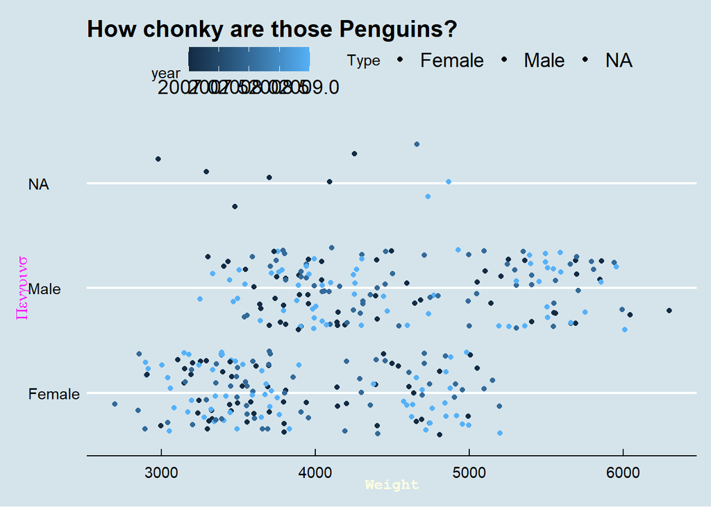

```r
## bad plot
# did not remove NAs in sex and species

penguins <- penguins %>%
  mutate(sex = recode(sex, 'male' = "Male", 'female' = "Female")) %>%   #change to proper capitalization
 write_csv(here("Week_8","Data","PenguinData.csv"))


ggplot(data = penguins,
       mapping = aes(x = body_mass_g, #compare species for body mass,
                     y = sex,# changed y to lose context
                     color = year, # added unnecessary year by color legend
                     fill = sex), #fill color sex
       stat = "identity") +  #took out facet grid to lose species categorization
  geom_jitter() + #jitter does not portray a clear picture of the data
  labs(title = "How chonky are those Penguins?", #uninformative title & no caption
       x = "Weight", # switched labels to match data, does not match title (Body Mass)
       y = "Penguins", #change y axis label
       fill = "Type")+ # legend label is too ambiguous and in the wrong place
  theme_economist() + #the theme does not match the figure
  theme(axis.title.x = element_text(color = "lightyellow", face = 11), #change axis text color, matches with background and is cramped
        axis.title.y = element_text(color = "magenta", face = 5))+ # illegible, wrong language
  ggsave(here("Week_7", "Output", "Bad_Plot.png"), #save plot
         width = 7, height = 5)
```

### Why it’s a Bad Plot

- The data set is unfiltered an includes incomplete cases, adding outliers in the plot
- The code is disorganized
- The X and Y axis organization is inverted and not the best way to portray the data
- There is unnecessary data/ color coding such as the year by color legend
- The data is unorganized, there is no facet wrapping for species categorization and the aesthetics are messy
- geom_jitter is not the best visualization method in this case.
- None of the labels are correct, the title is misleading/ wrongly formatted, there is no caption citing sources, the wording is not relevant to the context and the color makes some words illegible.
- The axis labels are ambiguous, mismatched and in the wrong language
- The theme does not match the plot and is misleading
- The legend is irrelevant and repetitive

# Good Plot

### Annotated Code

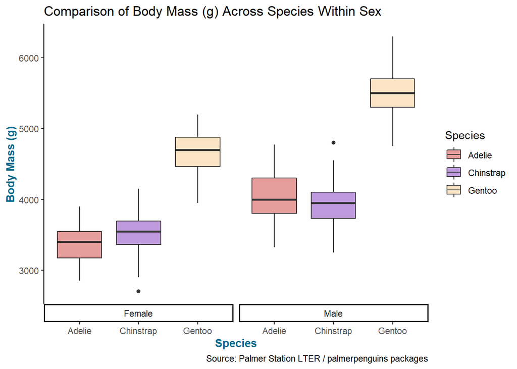

```r
#### Create boxplot ##################################################
penguins <- na.omit(penguins) #remove NAs in sex and species

penguins <- penguins %>%
  mutate(sex = recode(sex, 'male' = "Male", 'female' = "Female")) #change to proper capitalization

ggplot(data = penguins,
       mapping = aes(x = species, #compare species for body mass (g)
                     y = body_mass_g,
                     fill = species), #fill color species
       stat = "identity") +
  geom_boxplot() +
  facet_grid(~sex, switch = "x") + #facet for sex within species
  scale_fill_manual(values = pnw_palette(11)[c(4, 2, 6)]) + #PNW palette fill
  labs(title = "Comparison of Body Mass (g) Across Species Within Sex", #add title
       x = "Species", #change x axis label
       y = "Body Mass (g)", #change y axis label
       fill = "Species", #change legend label
       caption = "Source: Palmer Station LTER / palmerpenguins packages") + #add caption
  theme_classic() + #change theme
  theme(axis.title.x = element_text(color = "deepskyblue4", face = 2), #change axis text color
        axis.title.y = element_text(color = "deepskyblue4", face = 2))+
  ggsave(here("Week_7", "Output", "Good_Plot.png"), #save plot
         width = 7, height = 5)
```

Figure 2: Plot of body mass (g) by sex across three species.

### Why it’s a Good Plot

- The code is annotated and segmented for clarity & reproducibility
- The data was manipulated to show M/F and omit any NA values from the beginning
- The boxplot clearly represents the data and there is no ambiguity
- The plot is clearly labeled in addition to having a descriptive caption and a legend.
- The color scheme and font color are not distracting
- The labels are short and concise